# Twitter Network Exploration

A visual exploration of tweets on NASDAQ 100 stocks

Oamar Gianan

October 16, 2016

## About the Dataset

- Source:
  - [Follow The Hashtag](http://followthehashtag.com/datasets/nasdaq-100-companies-free-twitter-dataset/)
- Measured time:
  - From 2016-Mar-28 to 2016-Jun-15
  - 79 days
- Format:
  - 6 Excel files per company
- Twitter Stream:
  - Included in “Dashboad” file in Sheet named Stream
  - Retweets are included in this datasets
- Size:
  - 178 Mb (compressed)

## Questions

As a network analysis, I wanted to find out the following:

- Who are the top influentials?
- Who is the most influential user?
- Which stocks are the most influential users talking about?
- Which events caused the most chatter?

## Preparing the Dataset

### xlsx2csv

- A python utility which easily converts xlsx files to csv. Supports conversion of xlsx files with multiple sheets.
- Can be automated using bash scripting.
- [for more info](https://github.com/dilshod/xlsx2csv)

## The Dataset

### Dataframe attributes

```
## [1] 681941     27
```

- Relevant columns
  - Tweet ID - int, unique tweet identifier
  - Date, Hour - date, date and time of tweet
  - Nickname - char, twitter username
  - Tweet content - char
  - RTs - int, number of times retweeted
  - Followers - int, number of followers
  - Is a RT - logical, TRUE == retweet
  - User Mentions - char, other usernames mention in the tweet content
  - Symbols - char, NASDAQ symbols in the tweet content

### Number of unique users (based on Nickname)

```
## [1] 96613
```

### Number of unique tweets (based on Tweet Id, RTs recieve a unique Tweet ID too)

```
## [1] 681941
```

## The Most Talked About Stock

A wordcloud derived from the whole stream was generated to show the most talked about stock.

**Figure 1. Wordcloud of the frequestly mentioned stock symbols.**

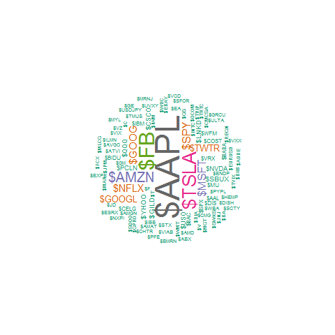

## Significant Events

When was there the most tweets?

The plot below shows the distribution of tweets and retweets during the course of the observation.

**Figure 2. Frequency plot over the whole stream.**

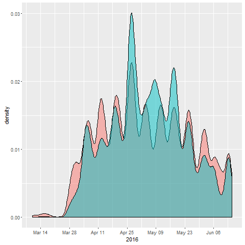

### Day of Max Tweets

At what time during Apr 27 did users tweet?

**Figure 3. Frequency plot of the day of maximum tweet count.**

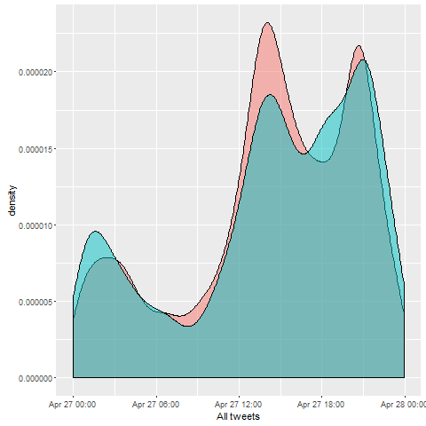

## Measure of Influence

Three measures of influence [^1] :

1. Indegree influence.
   - The number of people who follow a user.
   - Directly indicates the audience size of the user.
2. Retweet influence.
   - The number of times others “forward” a user’s tweet.
   - Represents the ability of the user to create content with pass-along value.
3. Mention.
   - The number of times others mention a user’s name.
   - Represents the ability of the user to engage others in a conversation.

## How Ranking Was Done

[Fractional rank](https://en.wikipedia.org/wiki/Ranking)

- Rank of 1 is given to the most influential user and increasing rank indicates a less influential user. Users with the same influence score recieves the average of the rank amongst them.

### Deriving Indegree influence rank

Select relevant columns: * Nickname - twitter username * Followers

```
## # A tibble: 6 × 2
##         Nickname Followers
##            <chr>     <dbl>
## 1        scutify      2039
## 2  halifaxbroker      1792
## 3 TradeWithSuper      1589
## 4       WKRBNews       771
## 5     ProVesting       788
## 6      midetimes      1171
```

## Deriving Retweet influence rank

- Filter to get tweets with unique Tweet ID.
- Select relevant columns:
  - Nickname
  - Is a RT - logical
  - RTs - integer count of the number of times the tweet was retweeted

```
##         Nickname TotalRT retwRank
## 1        scutify      76    398.0
## 2  halifaxbroker       5   2933.5
## 3 TradeWithSuper     100    304.0
## 4       WKRBNews     118    266.0
## 5     ProVesting      62    478.0
## 6      midetimes      29    865.0
```

## Deriving Mention influence rank

- Filter to get tweets with unique Tweet ID & Is NOT a RT
- Select relevant columns:
  - Nickname
  - User Mentions - char string which lists the usernames mentioned in the tweet

```
##         Nickname TotalMentions menRank
## 1        scutify            11   554.0
## 2  halifaxbroker             0 51046.5
## 3 TradeWithSuper             0 51046.5
## 4       WKRBNews             2  2410.5
## 5     ProVesting             1  4163.5
## 6      midetimes             0 51046.5
```

## The Top Influentials

Top 30 Influencers per Category

| Rank | TopIndegree | TopRT | TopMentions |
| --- | --- | --- | --- |
| 1 | cnnbrk | philstockworld | jimcramer |
| 2 | nytimes | StocksHighAlert | CNBC |
| 3 | CNN | ValaAfshar | AlertTrade |
| 4 | Reuters | YahooFinance | WSJ |
| 5 | WSJ | BK_Stocks | Benzinga |
| 6 | Forbes | businessinsider | YahooFinance |
| 7 | AP | StockTwits | CNBCFastMoney |
| 8 | DRJAMESCABOT | timothysykes | TheStreet |
| 9 | GMA | CNNMoney | autumnalcity87 |
| 10 | MarketWatch | devonshiretech | carlquintanilla |
| 11 | JohnLegere | CNBCnow | HalftimeReport |
| 12 | USATODAY | ppprophet | markbspiegel |
| 13 | CNBC | carlquintanilla | RiskReversal |
| 14 | ForbesTech | Stockology101 | petenajarian |
| 15 | FortuneMagazine | Benzinga | TTtradertwit |
| 16 | timoreilly | OpenOutcrier | GerberKawasaki |
| 17 | rsAnakin_FBGx20 | marketexclusive | barronsonline |
| 18 | philstockworld | DayTradersGroup | ReformedBroker |
| 19 | dickc | theflynews | Reuters |
| 20 | ReutersBiz | TakeFlightSales | GuyAdami |
| 21 | businessinsider | WrigleyTom | StockTwits |
| 22 | om | TweakTown | RedDogT3 |
| 23 | Yahoo | markbspiegel | jonnajarian |
| 24 | SAI | SAI | cek_cpa |
| 25 | globeandmail | WSJ | JustinPulitzer |
| 26 | Variety | CenterTrading | ryanwallace198 |
| 27 | VH1 | CBOE | DougKass |
| 28 | CNNMoney | davidmoadel | technology |
| 29 | WSJbusiness | GerberKawasaki | BossHoggHazzard |
| 30 | CNET | options_answers | SquawkStreet |

Marginal overlaps were observed in these three top lists. The top `25` lists only had one user in common, `WSJ`

**Figure 4. Venn diagram of the top 100 influentials across measures.**

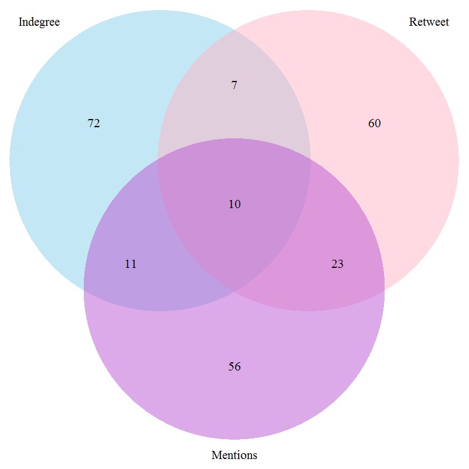

The top 100 lists also showed marginal overlap.

## Spearman’s Correlation Coefficient

What rank matters the most?

The correlation done on the top influential users show a stronger correlation in their retweet influence and mention influence.

**Figure 5. Correlation plot across measures.**

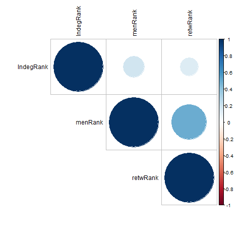

This means that in most cases, users who are retweeted often are also mentioned often, and vice versa.

## Network Graph

Creating a network object of the whole twitter stream involves the following data frames:

- Nodes - or vertices. In this case, all unique twitter users.
- Edges - or links. In this case, retweets and mentions.

Nodes and edges may have weights.

The `igraph` library is required to create the network object.

## Network attributes

A look at the resulting network shows the following attributes.

```
## IGRAPH DNW- 96613 168519 --
## + attr: name (v/c), Followers (v/n), type (e/c), weight (e/n)
## + edges (vertex names):
##  [1] ______NGS______->BluegrassCap    ______NGS______->BrattleStCap
##  [3] ______NGS______->FatTailCapital  ______NGS______->FatTailCapital
##  [5] ______NGS______->Find_Me_Value   ______NGS______->inner_scorecard
##  [7] ______NGS______->KerrisdaleCap   ______NGS______->Liberty8988
##  [9] ______NGS______->LongShortTrader ______NGS______->MaglanCapital
## [11] ______NGS______->MarAzul_90      ______NGS______->max02050
## [13] ______NGS______->maxvision33     ______NGS______->MugatuCapital
## [15] ______NGS______->NickatFP        ______NGS______->SkeleCap
## + ... omitted several edges
```

Network is **TOO BIG!**

## Creating a smaller network

To create a smaller network, the twitter stream of a single company is read and loaded.

A more manageable network object was created.

```
## IGRAPH DNW- 431 181 --
## + attr: name (v/c), Followers (v/n), weight (e/n)
## + edges (vertex names):
##  [1] _bagholder_    ->ppprophet      20trilliondeb  ->ppprophet
##  [3] 7LadyQ         ->eWhispers      7LadyQ         ->OpenOutcrier
##  [5] 7LadyQ         ->WrigleyTom     AdaptToReality ->AdaptToReality
##  [7] adelivania     ->Benzinga       AdvisorboxMedia->MorningstarInc
##  [9] Alain_2012a    ->Boursier_com   alekskrug8     ->SleekMoneycom
## [11] AlertTrade     ->AlertTrade     allgringo      ->ChinaInvest
## [13] AlphSt_Live    ->Opinterest     AltruistWealth ->eWhispers
## [15] aTGelstmM      ->PersonsPlanet  ATPFtrading    ->gouluk1
## + ... omitted several edges
```

## Network Analysis

### Density

The proportion of present edges from all possible edges in the network.

```
## [1] 0.0009766363
```

### Diameter

The diameter of a graph is the length of the longest geodesic.

```
## [1] 9
```

```
## + 10/431 vertices, named:
##  [1] TachyonGlobalLL StakepoolCom    LMTentarelli    tamaraspen2
##  [5] ppprophet       diggingplatinum WrigleyTom      nixonstocks
##  [9] ACInvestorBlog  ProbabilityOne
```

**Figure 6. Network graph showing the diameter.**

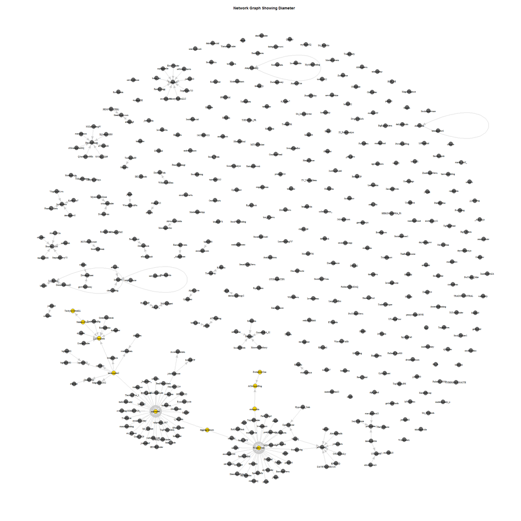

## Hubs and authorities

The hubs and authorities algorithm developed by Jon Kleinberg was initially used to examine web pages.

- Hubs - more outgoing links
  - similar to a catalog with links to other pages.
- Authorities - more incoming links
  - presumably because of their high-quality relevant information.

### Hub

**Figure 7. Hub network graph.**

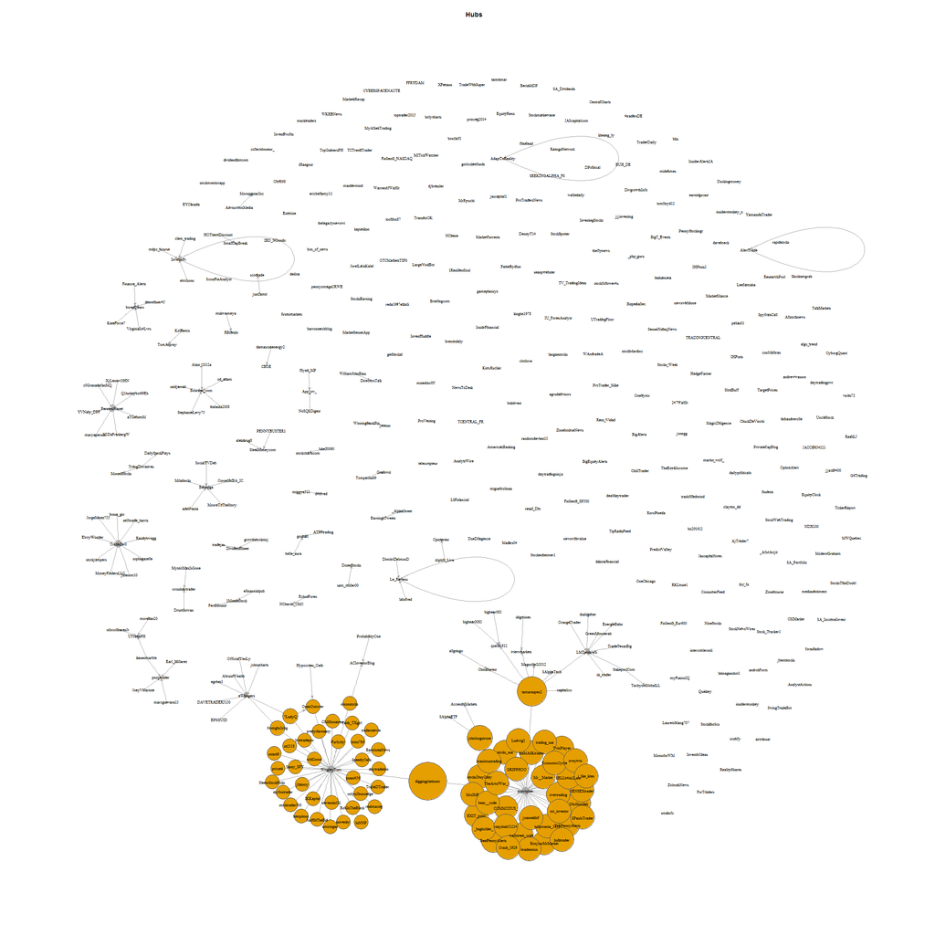

### Authority

**Figure 8. Authority network graph.**

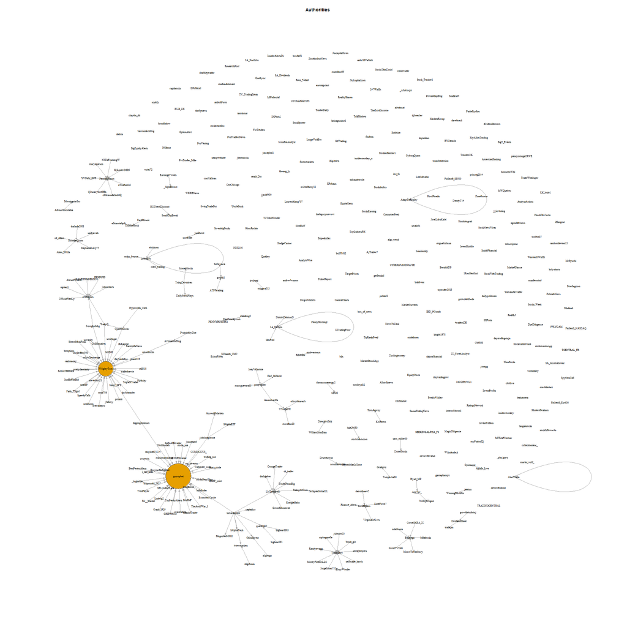

[^1]: *Measuring User Influence in Twitter: The Million Follower Fallacy, Cha, Haddadi, Benevenuto, Gummadi. 2010*